# AJP PG Publication Code

Abby Beatty

May 29, 2020

##Load Necessary Packages

```r
library(ggplot2)
library(nlme)
library(multcomp)
library(emmeans)
library(MuMIn)
library(bestNormalize)
library(lmtest)
```

##Summary Function for Mean and specifications for graphing parameters

```r
summarySE <- function(data=NULL, measurevar, groupvars=NULL, na.rm=TRUE,
                      conf.interval=.95, .drop=TRUE) {
    library(plyr)
    # New version of length which can handle NA's: if na.rm==T, don't count them
    length2 <- function (x, na.rm=TRUE) {
        if (na.rm) sum(!is.na(x))
        else       length(x)
    }
    # This does the summary. For each group's data frame, return a vector with
    # N, mean, and sd
    datac <- ddply(data, groupvars, .drop=.drop,
      .fun = function(xx, col) {
        c(N    = length2(xx[[col]], na.rm=na.rm),
          mean = mean   (xx[[col]], na.rm=na.rm),
          sd   = sd     (xx[[col]], na.rm=na.rm)
        )
      },
      measurevar
    )
    # Rename the "mean" column
    datac <- rename(datac, c("mean" = measurevar))
    datac$se <- datac$sd / sqrt(datac$N)  # Calculate standard error of the mean
    # Confidence interval multiplier for standard error
    # Calculate t-statistic for confidence interval:
    # e.g., if conf.interval is .95, use .975 (above/below), and use df=N-1
    ciMult <- qt(conf.interval/2 + .5, datac$N-1)
    datac$ci <- datac$se * ciMult
    return(datac)
}
pd <- position_dodge(0.02)
dodge <- position_dodge(width = 0.6)
```

##READ IN AND CALCULATE AVERAGES

```r
Q=read.csv("combined.final.csv")
EEF2=subset(Q, Target == "EEF2")
IGFs=subset(Q, Target== "IGF1" | Target== "IGF2")
IGF1=subset(IGFs, Target == "IGF1")
IGF2=subset(IGFs, Target == "IGF2")

samplesize=summarySE(Q, measurevar="Copy_Number", groupvars=c("Sample", "Life_Stage"))
```

> With the intent to run linear models, the data was tested for the required assumptions.

#Test of Assumptions for linear models

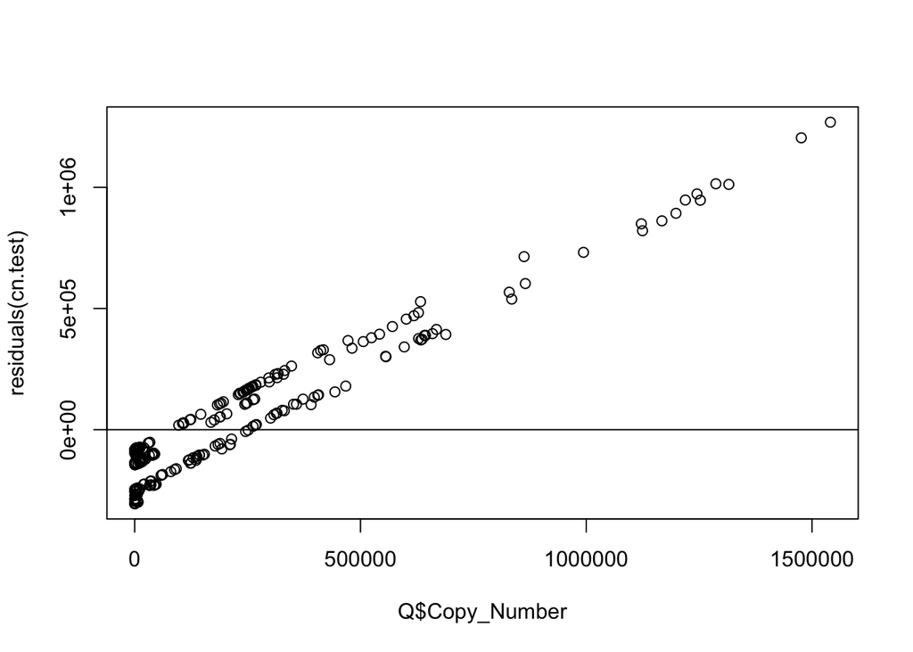

```r
#Statistical and visual test of heteroscedasticity
#All data
cn.test=lme(Copy_Number~Life_Stage, data = Q, na.action=na.omit, random=~1|Sample)
plot(Q$Copy_Number, residuals(cn.test))
abline(a=0,b=0)
```

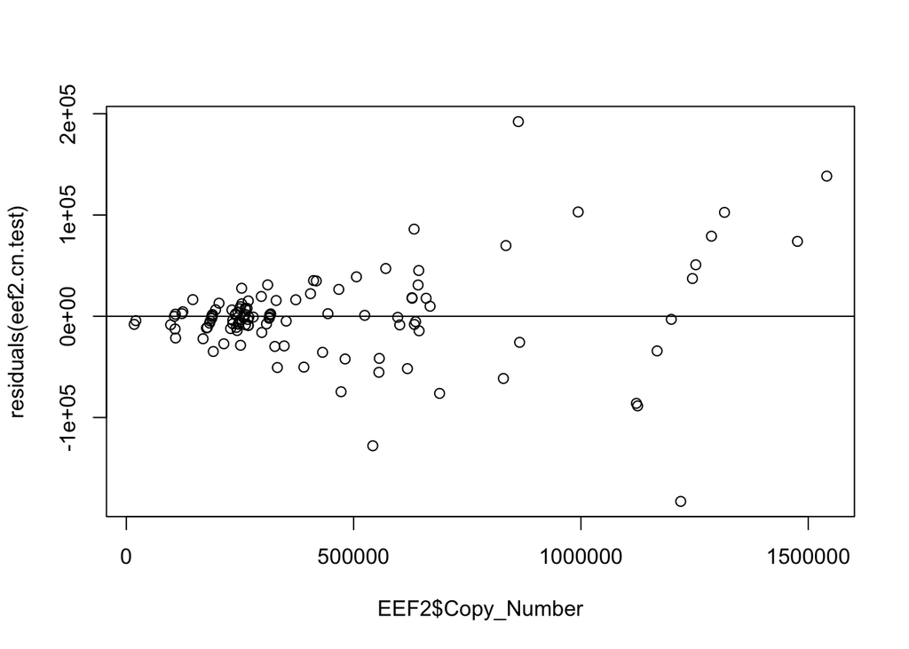

```r
#EEF2
eef2.cn.test=lme(Copy_Number~Life_Stage, data = EEF2, na.action=na.omit, random=~1|Sample)
#Residuals plot
plot(EEF2$Copy_Number, residuals(eef2.cn.test))
abline(a=0,b=0)
```

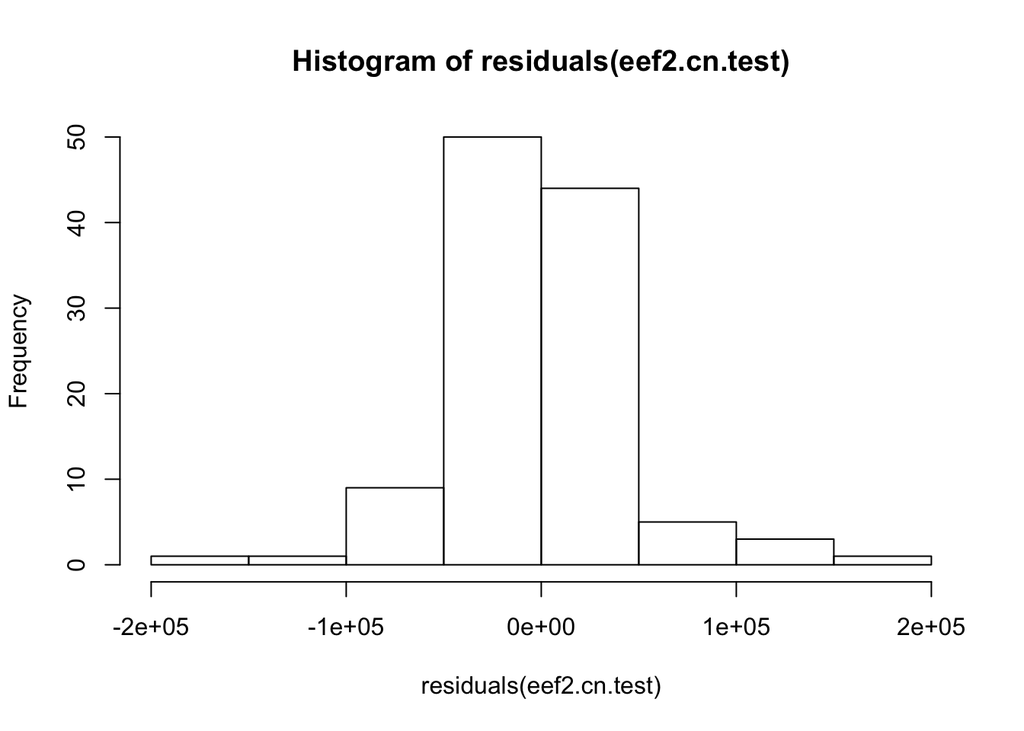

```r
#Secondary Histogram to assess normality.
hist(residuals(eef2.cn.test))
```

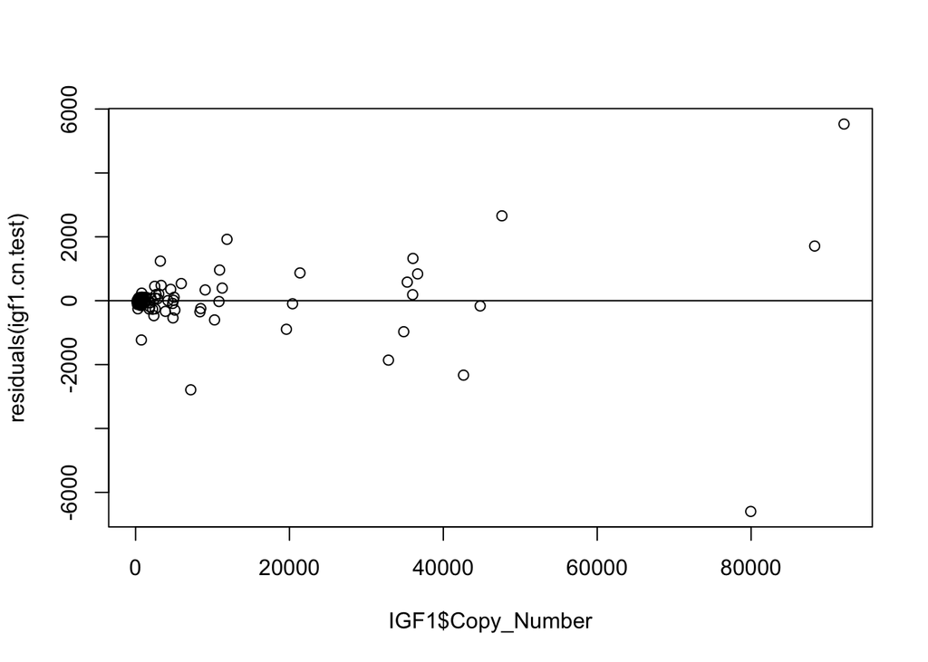

```r
#IGF1
igf1.cn.test=lme(Copy_Number~Life_Stage, data = IGF1, na.action=na.omit, random=~1|Sample)
#Residuals plot
plot(IGF1$Copy_Number, residuals(igf1.cn.test))
abline(a=0,b=0)
```

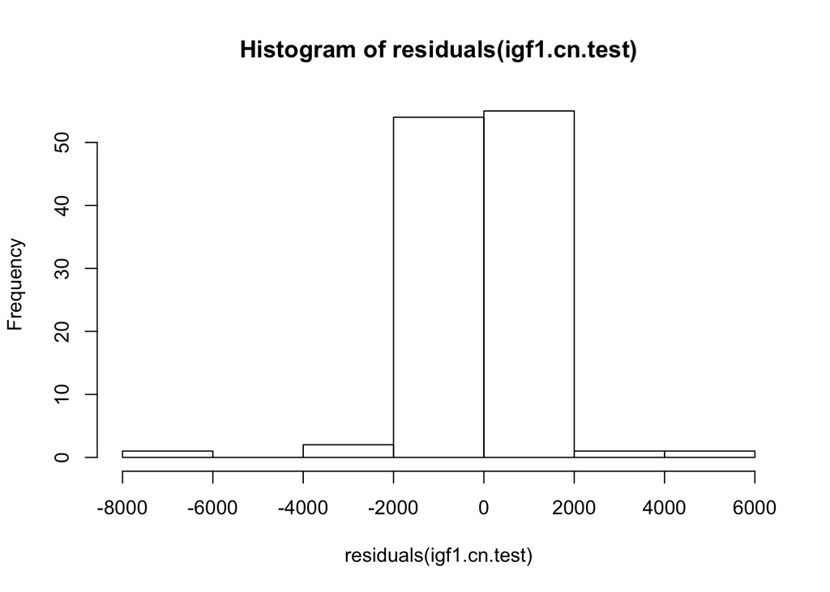

```r
#Secondary Histogram to assess normality.
hist(residuals(igf1.cn.test))
```

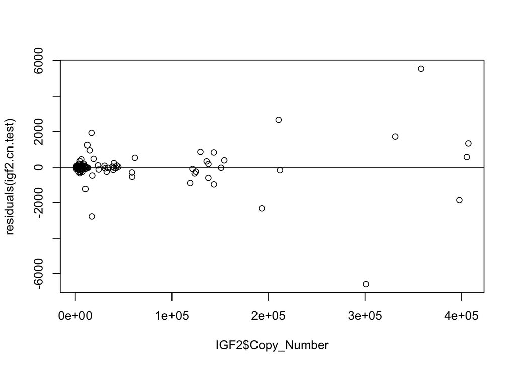

```r
#IGF2
igf2.cn.test=lme(Copy_Number~Life_Stage, data = IGF1, na.action=na.omit, random=~1|Sample)
#Residuals plot
plot(IGF2$Copy_Number, residuals(igf2.cn.test))
abline(a=0,b=0)
```

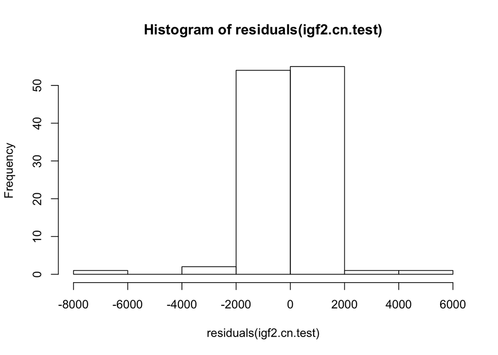

```r
#Secondary Histogram to assess normality.
hist(residuals(igf2.cn.test))
```

>All genes fail the assumption for heteroscedasticity and normality. Data will be transformed to meet assumptions of the linear mixed model. In order to identify the best normalization method for our data, the bestNormalize package was used. Those results can be seen below.

##Identification of possible transformation models by BestNormalize

```r
#analysis of whole data set (IGFs + EEF2)
bestNormalize(Q$Copy_Number)
```

```
## Best Normalizing transformation with 342 Observations
##  Estimated Normality Statistics (Pearson P / df, lower => more normal):
##  - arcsinh(x): 2.4187
##  - Box-Cox: 2.4592
##  - Log_b(x+a): 2.4187
##  - No transform: 12.5876
##  - orderNorm (ORQ): 1.2209
##  - sqrt(x + a): 6.0455
##  - Yeo-Johnson: 2.4767
## Estimation method: Out-of-sample via CV with 10 folds and 5 repeats
##
## Based off these, bestNormalize chose:
## orderNorm Transformation with 342 nonmissing obs and no ties
##  - Original quantiles:
##          0%         25%         50%         75%        100%
##     180.823    2499.214   13899.809  248348.545 1540696.253
```

```r
#analysis of EEF2 alone
bestNormalize(EEF2$Copy_Number)
```

```
## Best Normalizing transformation with 114 Observations
##  Estimated Normality Statistics (Pearson P / df, lower => more normal):
##  - arcsinh(x): 1.8176
##  - Box-Cox: 1.9491
##  - Log_b(x+a): 1.8176
##  - No transform: 2.7721
##  - orderNorm (ORQ): 1.3097
##  - sqrt(x + a): 2.0739
##  - Yeo-Johnson: 1.9491
## Estimation method: Out-of-sample via CV with 10 folds and 5 repeats
##
## Based off these, bestNormalize chose:
## orderNorm Transformation with 114 nonmissing obs and no ties
##  - Original quantiles:
##         0%        25%        50%        75%       100%
##   17348.68  240959.83  309675.78  600364.19 1540696.25
```

```r
#analysis of IGFs
bestNormalize(IGFs$Copy_Number)
```

```
## Best Normalizing transformation with 228 Observations
##  Estimated Normality Statistics (Pearson P / df, lower => more normal):
##  - arcsinh(x): 1.3695
##  - Box-Cox: 1.4005
##  - Log_b(x+a): 1.3695
##  - No transform: 12.7765
##  - orderNorm (ORQ): 1.2049
##  - sqrt(x + a): 4.9674
##  - Yeo-Johnson: 1.3977
## Estimation method: Out-of-sample via CV with 10 folds and 5 repeats
##
## Based off these, bestNormalize chose:
## orderNorm Transformation with 228 nonmissing obs and no ties
##  - Original quantiles:
##         0%        25%        50%        75%       100%
##    180.823    850.151   4784.153  13473.974 407093.556
```

> For all three tests, the ordered quantile transformation was indicated as the most appropriate transformation method.

#DETERMINE THE EFFICIENCY OF EEF2 HAS A HOUSEKEEPING GENE ##Ordered Quantile transformation of all data

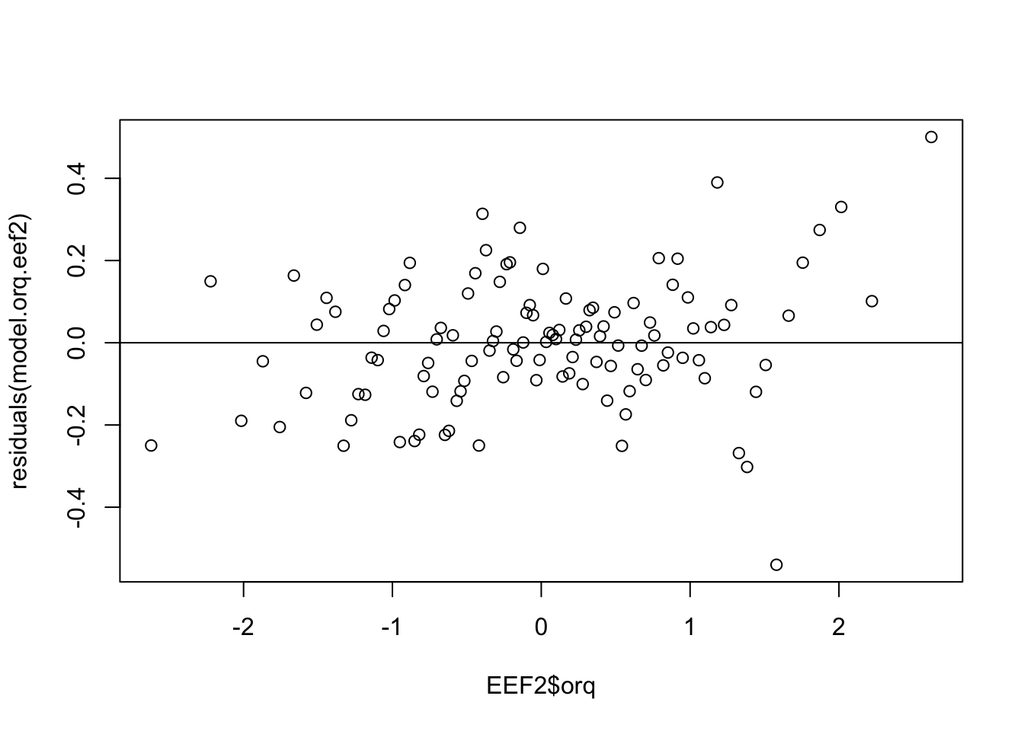

```r
orq=orderNorm(EEF2$Copy_Number)
EEF2=cbind(EEF2, orq=orq$x.t)

#Transformed Data Evaluation
model.orq.eef2=(lme(orq~Life_Stage, random =  ~1|Sample, data=EEF2))

plot(EEF2$orq, residuals(model.orq.eef2))
abline(a=0,b=0)
```

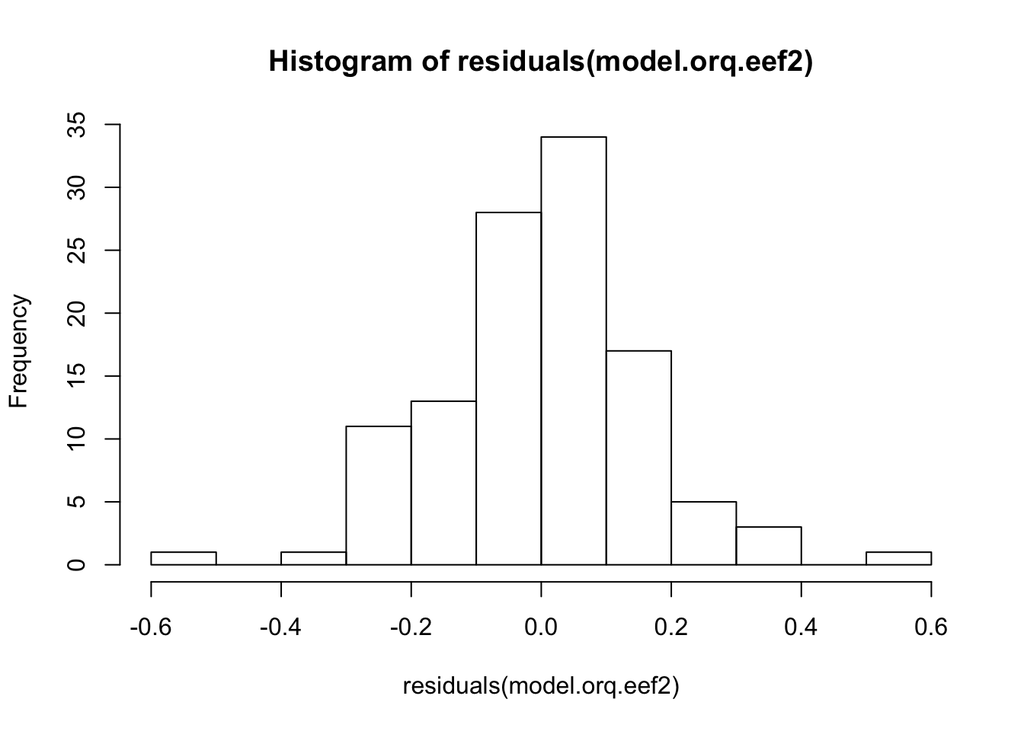

```r
hist(residuals(model.orq.eef2))
```

```r
#ORQ
##Run a lme to determine if there is significant variation in expression of the referene gene across life stages. The signficinat p values indicate that expression of the gene varies between sample stages, and is therefore not a suitable normalizing gene.
post.test.orq=lme(orq~Life_Stage, data = EEF2, na.action=na.omit, random=~1|Sample)
anova(post.test.orq)
```

```
##             numDF denDF  F-value p-value
## (Intercept)     1    71 0.004600  0.9461
## Life_Stage      6    36 4.088039  0.0032
```

```r
#Run a post-hoc test in the standard Tukey setup to get adjust p-values for pairwise comparison between groups
summary(glht(post.test.orq, linfct=mcp(Life_Stage="Tukey")))
```

```
##
##   Simultaneous Tests for General Linear Hypotheses
##
## Multiple Comparisons of Means: Tukey Contrasts
##
##
## Fit: lme.formula(fixed = orq ~ Life_Stage, data = EEF2, random = ~1 |
##     Sample, na.action = na.omit)
##
## Linear Hypotheses:
##                         Estimate Std. Error z value Pr(>|z|)
## Day 0 - Adult == 0      -0.38637    0.41717  -0.926  0.96732
## Stage 16 - Adult == 0   -0.89032    0.56546  -1.575  0.69194
## Stage 2 - Adult == 0     0.86805    0.51112   1.698  0.60975
## Stage 6 - Adult == 0     0.70470    0.51073   1.380  0.80787
## Week 4 - Adult == 0     -0.93882    0.41717  -2.250  0.26202
## Week 8 - Adult == 0     -0.86279    0.41693  -2.069  0.36366
## Stage 16 - Day 0 == 0   -0.50395    0.56581  -0.891  0.97309
## Stage 2 - Day 0 == 0     1.25441    0.51151   2.452  0.17177
## Stage 6 - Day 0 == 0     1.09107    0.51112   2.135  0.32503
## Week 4 - Day 0 == 0     -0.55246    0.41764  -1.323  0.83706
## Week 8 - Day 0 == 0     -0.47642    0.41741  -1.141  0.91260
## Stage 2 - Stage 16 == 0  1.75837    0.63824   2.755  0.08250 .
## Stage 6 - Stage 16 == 0  1.59502    0.63793   2.500  0.15455
## Week 4 - Stage 16 == 0  -0.04850    0.56581  -0.086  1.00000
## Week 8 - Stage 16 == 0   0.02753    0.56563   0.049  1.00000
## Stage 6 - Stage 2 == 0  -0.16335    0.59030  -0.277  0.99996
## Week 4 - Stage 2 == 0   -1.80687    0.51151  -3.532  0.00725 **
## Week 8 - Stage 2 == 0   -1.73083    0.51131  -3.385  0.01208 *
## Week 4 - Stage 6 == 0   -1.64352    0.51112  -3.216  0.02119 *
## Week 8 - Stage 6 == 0   -1.56749    0.51093  -3.068  0.03362 *
## Week 8 - Week 4 == 0     0.07604    0.41741   0.182  1.00000
## ---
## Signif. codes:  0 '***' 0.001 '**' 0.01 '*' 0.05 '.' 0.1 ' ' 1
## (Adjusted p values reported -- single-step method)
```

```r
#variance test
var=(aov(orq~Life_Stage, data=EEF2))
summary(var)
```

```
##              Df Sum Sq Mean Sq F value   Pr(>F)
## Life_Stage    6  43.96   7.327    11.4 7.99e-10 ***
## Residuals   107  68.77   0.643
## ---
## Signif. codes:  0 '***' 0.001 '**' 0.01 '*' 0.05 '.' 0.1 ' ' 1
```

```r
anova(var)
```

```
## Analysis of Variance Table
##
## Response: orq
##             Df Sum Sq Mean Sq F value    Pr(>F)
## Life_Stage   6 43.962  7.3270  11.401 7.988e-10 ***
## Residuals  107 68.766  0.6427
## ---
## Signif. codes:  0 '***' 0.001 '**' 0.01 '*' 0.05 '.' 0.1 ' ' 1
```

```r
TukeyHSD(var)
```

```
##   Tukey multiple comparisons of means
##     95% family-wise confidence level
##
## Fit: aov(formula = orq ~ Life_Stage, data = EEF2)
##
## $Life_Stage
##                         diff        lwr        upr     p adj
## Day 0-Adult      -0.38165148 -1.1110637  0.3477607 0.7000298
## Stage 16-Adult   -0.79968204 -1.8345705  0.2352064 0.2432500
## Stage 2-Adult     0.82575099 -0.0810274  1.7325294 0.0992026
## Stage 6-Adult     0.70760791 -0.1695936  1.5848094 0.1988571
## Week 4-Adult     -0.93499385 -1.6644061 -0.2055816 0.0036687
## Week 8-Adult     -0.90444306 -1.6155408 -0.1933454 0.0040646
## Stage 16-Day 0   -0.41803055 -1.4760294  0.6399683 0.8974800
## Stage 2-Day 0     1.20740247  0.2743352  2.1404697 0.0032335
## Stage 6-Day 0     1.08925940  0.1849088  1.9936100 0.0079925
## Week 4-Day 0     -0.55334237 -1.3151886  0.2085039 0.3136057
## Week 8-Day 0     -0.52279158 -1.2671218  0.2215386 0.3540033
## Stage 2-Stage 16  1.62543302  0.4381814  2.8126846 0.0014522
## Stage 6-Stage 16  1.50728995  0.3424716  2.6721083 0.0032336
## Week 4-Stage 16  -0.13531181 -1.1933106  0.9226870 0.9997369
## Week 8-Stage 16  -0.10476102 -1.1502175  0.9406955 0.9999368
## Stage 6-Stage 2  -0.11814307 -1.1707849  0.9344988 0.9998771
## Week 4-Stage 2   -1.76074484 -2.6938121 -0.8276776 0.0000025
## Week 8-Stage 2   -1.73019405 -2.6490152 -0.8113729 0.0000027
## Week 4-Stage 6   -1.64260176 -2.5469524 -0.7382512 0.0000064
## Week 8-Stage 6   -1.61205097 -2.5016957 -0.7224062 0.0000068
## Week 8-Week 4     0.03055079 -0.7137794  0.7748810 0.9999997
```

[figure not shown]

```r
EEF2.plot= ggplot(EEF2, aes(x=as.factor(Life_Stage), y=orq)) +
  #this line creates a violin plot, not trimming the shape to hide data density on ends, and setting the width of the violins     to line up with the groups on the x axis.
  geom_violin(trim=F, position= dodge, scale="width") +
  #A boxplot is overlayed on the violin plot to show the mean and quartiles of the data, and all dataset outlies are        highlighted in red.
  geom_boxplot(width=0.1, position= dodge, outlier.color = "red") +
  #the data points at each life stage are then placed on top of the boxplots to show the data distribution
  geom_point(position=dodge) +
  #change the y-axis to scientific notation
  scale_y_continuous(labels = function(x) format(x, scientific = TRUE)) +
  #Rename the x axis to display the developmental stages in "mid, early, and late" rather than numberical stages
  scale_x_discrete(name ="Life Stage",
                   labels=c("Early-Dev", "Mid-Dev", "Late-Dev", "Day 0", "Week 4", "Week 8", "Adult")) +
  #change the y axis title to remove the underscore in coded dataframe
  ylab("Copy Number ORQ Transformed") +
  #bold the text on the axis titles
  theme(axis.title = element_text(face="bold", size=16)) +
  theme(axis.text = element_text(face="bold")) +
  theme(axis.text = element_text(size=14)) +
  theme(plot.title = element_text(face="bold", size=16)) +
  #remove legend from the plot
  theme(legend.position="none") +
  #add a title to the plot
  ggtitle("EEF2 Not Valid Ref Gene (ORQ)")


ggsave(EEF2.plot, file="EEF2.norm.trans.png", width=12, height=10, dpi=300)

EEF2.plot
```

> The above shows that EEF2 has significant variance across time-points, making it not suitable for normalization. Therefore, data will not be normalized by this reference gene.

#Anlaysis of IGF1 and IGF2

```r
#Veryify that after normalization, ORQ is still an appropriate transformation approach
bestNormalize(IGFs$Copy_Number)
```

```
## Best Normalizing transformation with 228 Observations
##  Estimated Normality Statistics (Pearson P / df, lower => more normal):
##  - arcsinh(x): 1.2976
##  - Box-Cox: 1.2658
##  - Log_b(x+a): 1.2976
##  - No transform: 13.0451
##  - orderNorm (ORQ): 1.2125
##  - sqrt(x + a): 5.1864
##  - Yeo-Johnson: 1.2658
## Estimation method: Out-of-sample via CV with 10 folds and 5 repeats
##
## Based off these, bestNormalize chose:
## orderNorm Transformation with 228 nonmissing obs and no ties
##  - Original quantiles:
##         0%        25%        50%        75%       100%
##    180.823    850.151   4784.153  13473.974 407093.556
```

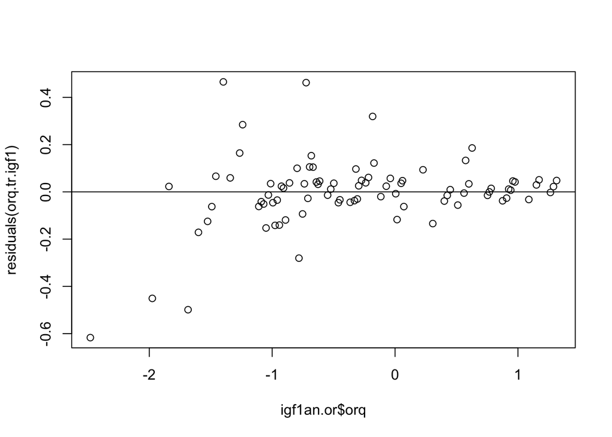

```r
#Obtained transformed values and bind to original data set
orq=orderNorm(IGFs$Copy_Number)
IGFs=cbind(IGFs, orq=orq$x.t)

#IGF1
#Transformed Data Evaluation
igf1.or=subset(IGFs, Target == "IGF1")
igf1an.or=subset(igf1.or, Life_Status =="Animal")
orq.tr.igf1=(lme(orq~Life_Stage, random =  ~1|Sample, data=igf1an.or))
plot(igf1an.or$orq, residuals(orq.tr.igf1))
abline(a=0,b=0)
```

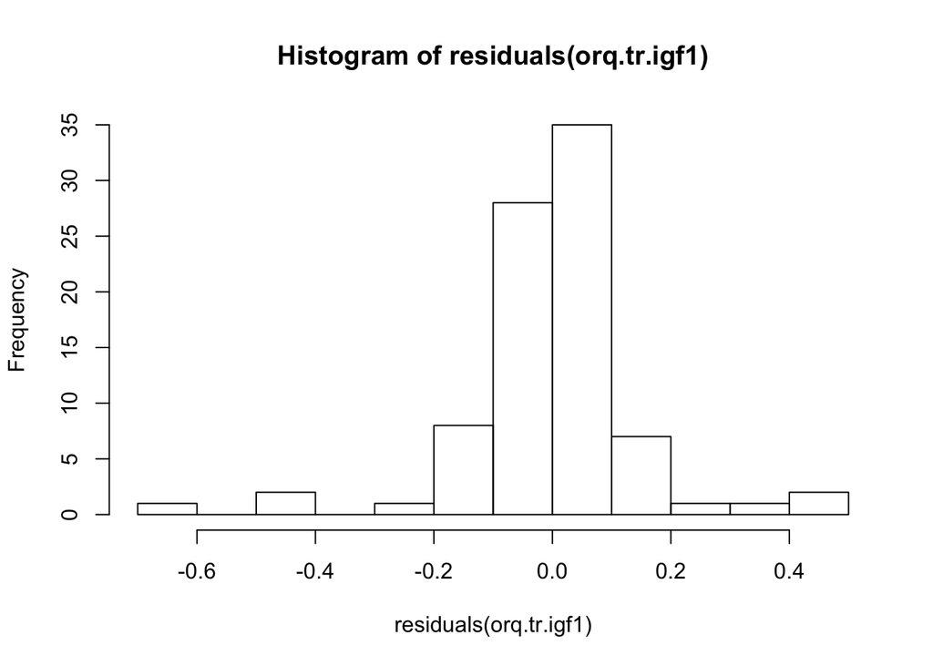

```r
hist(residuals(orq.tr.igf1))
```

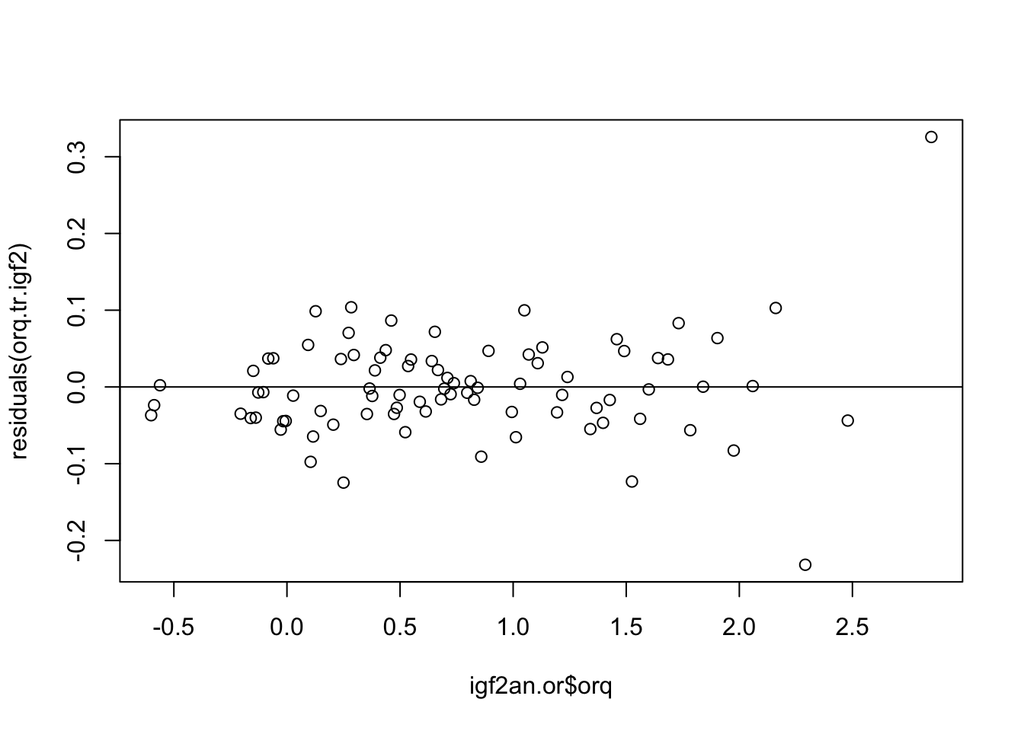

```r
#IGF2
#Transformed Data Evaluation
igf2.or=subset(IGFs, Target == "IGF2")
igf2an.or=subset(igf2.or, Life_Status =="Animal")
orq.tr.igf2=(lme(orq~Life_Stage, random =  ~1|Sample, data=igf2an.or))
plot(igf2an.or$orq, residuals(orq.tr.igf2))
abline(a=0,b=0)
```

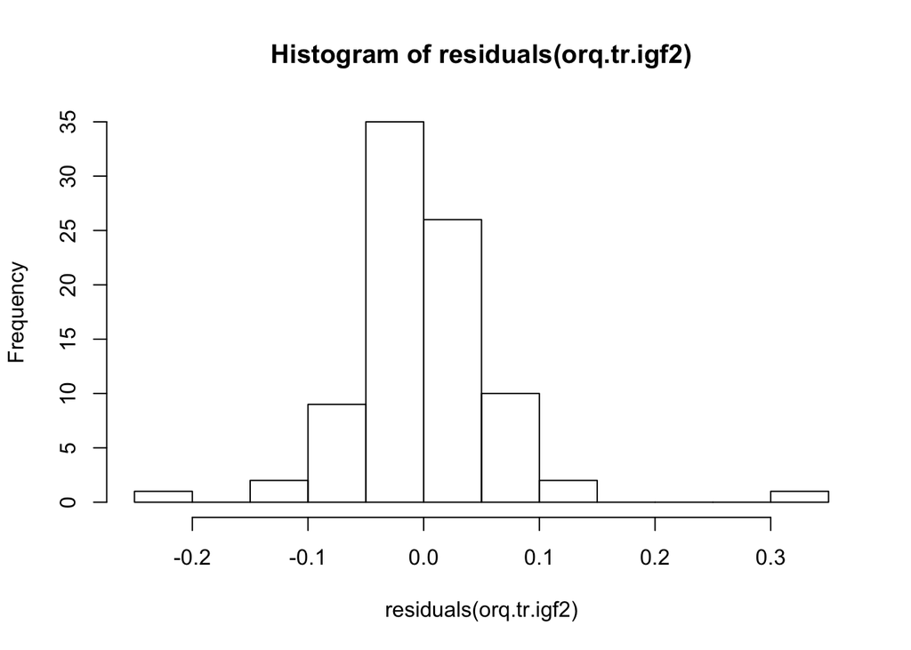

```r
hist(residuals(orq.tr.igf2))
```

#Determination of Statistical model using normalized and transformed data

```r
animal=subset(IGFs, Life_Status == "Animal")

model.igfs=(lme(orq~Life_Stage, random =  ~1|Sample, method="ML", data=animal))
summary(model.igfs)
```

```
## Linear mixed-effects model fit by maximum likelihood
##  Data: animal
##        AIC      BIC    logLik
##   386.0866 404.9716 -187.0433
##
## Random effects:
##  Formula: ~1 | Sample
##         (Intercept)  Residual
## StdDev:   0.1865816 0.6964809
##
## Fixed effects: orq ~ Life_Stage
##                      Value Std.Error  DF   t-value p-value
## (Intercept)       1.242625 0.1216625 140 10.213704       0
## Life_StageDay 0  -1.295910 0.1783407  28 -7.266488       0
## Life_StageWeek 4 -1.458196 0.1783407  28 -8.176466       0
## Life_StageWeek 8 -1.476354 0.1750093  28 -8.435860       0
##  Correlation:
##                  (Intr) Lf_SD0 Lf_SW4
## Life_StageDay 0  -0.682
## Life_StageWeek 4 -0.682  0.465
## Life_StageWeek 8 -0.695  0.474  0.474
##
## Standardized Within-Group Residuals:
##        Min         Q1        Med         Q3        Max
## -3.2033148 -0.7087124  0.1844213  0.7373649  2.0958987
##
## Number of Observations: 172
## Number of Groups: 32
```

```r
model.igfs.sex=(lme(orq~Life_Stage+Sex, random =  ~1|Sample, na.action=na.omit, method="ML", data=animal))
summary(model.igfs.sex)
```

```
## Linear mixed-effects model fit by maximum likelihood
##  Data: animal
##        AIC      BIC    logLik
##   388.0593 410.0918 -187.0297
##
## Random effects:
##  Formula: ~1 | Sample
##         (Intercept)  Residual
## StdDev:   0.1860917 0.6965219
##
## Fixed effects: orq ~ Life_Stage + Sex
##                       Value Std.Error  DF   t-value p-value
## (Intercept)       1.2530871 0.1378370 140  9.091082  0.0000
## Life_StageDay 0  -1.2989120 0.1796993  27 -7.228252  0.0000
## Life_StageWeek 4 -1.4589900 0.1788126  27 -8.159326  0.0000
## Life_StageWeek 8 -1.4763385 0.1754049  27 -8.416747  0.0000
## SexM             -0.0209244 0.1285442  27 -0.162780  0.8719
##  Correlation:
##                  (Intr) Lf_SD0 Lf_SW4 Lf_SW8
## Life_StageDay 0  -0.648
## Life_StageWeek 4 -0.616  0.465
## Life_StageWeek 8 -0.615  0.472  0.474
## SexM             -0.466  0.103  0.027  0.000
##
## Standardized Within-Group Residuals:
##        Min         Q1        Med         Q3        Max
## -3.2116773 -0.6975607  0.1805002  0.7418354  2.1070819
##
## Number of Observations: 172
## Number of Groups: 32
```

```r
anova(model.igfs, model.igfs.sex)
```

```
##                Model df      AIC      BIC    logLik   Test    L.Ratio p-value
## model.igfs         1  6 386.0866 404.9716 -187.0433
## model.igfs.sex     2  7 388.0593 410.0918 -187.0297 1 vs 2 0.02725563  0.8689
```

##STATISTICAL MEASUREMENTS OF IGF1 AND IGF2 ACROSS LIFE STAGES

```r
#Test for effect of sex in model. A random command is added to account for the triplicate measures during qPCR analysis.
model.igfs.sex=anova(lme(orq~Target+Sex, random =  ~1|Sample, data=IGFs, na=na.omit))
model.igfs.sex
```

```
##             numDF denDF  F-value p-value
## (Intercept)     1   139   2.1048  0.1491
## Target          1   139 361.1802  <.0001
## Sex             1    30   0.0056  0.9407
```

```r
#Test if relative expression of IGF1 and IGF2 is significant between life stages across the entire data set.
model.igfs=summary(lme(orq~Target, random =  ~1|Sample, data=IGFs))
model.igfs
```

```
## Linear mixed-effects model fit by REML
##  Data: IGFs
##        AIC      BIC    logLik
##   333.7274 347.4095 -162.8637
##
## Random effects:
##  Formula: ~1 | Sample
##         (Intercept)  Residual
## StdDev:   0.7412624 0.3647006
##
## Fixed effects: orq ~ Target
##                  Value  Std.Error  DF   t-value p-value
## (Intercept) -0.5853913 0.11817809 184 -4.953467       0
## TargetIGF2   1.0915034 0.04830577 184 22.595712       0
##  Correlation:
##            (Intr)
## TargetIGF2 -0.204
##
## Standardized Within-Group Residuals:
##         Min          Q1         Med          Q3         Max
## -3.44884367 -0.50769575  0.03612429  0.62717016  1.99282714
##
## Number of Observations: 228
## Number of Groups: 43
```

##SUBSETTING OF DATA BY LIFE STAGE. Relative IGF measures at each life stage. From this point on, data must be subsetted because the embryonic RNA extractions were whole organism, and the other samples were liver extractions. The two data types are not comparable.

```r
##Subset the IGF data set to seperate each life stage to run IGF1 vs IGF2 expression at each life stage. The whole model was significant, but this will determine whether or not IGF2 is higher at each life stage individually, or just over the entire model.
st2=subset(IGFs, Life_Stage == "Stage 2")
st6=subset(IGFs, Life_Stage == "Stage 6")
st16=subset(IGFs, Life_Stage == "Stage 16")
d0=subset(IGFs, Life_Stage == "Day 0")
w4=subset(IGFs, Life_Stage == "Week 4")
w8=subset(IGFs, Life_Stage == "Week 8")
adult=subset(IGFs, Life_Stage == "Adult")

##linear models are run comparing the expression levels (copy number) of IGF1 and IGF2 (target) at each life stage (data). A random command is added to account for the triplicate measures during qPCR analysis.
summary(lme(orq~Target, data=st2, random = ~1|Sample))
```

```
## Linear mixed-effects model fit by REML
##  Data: st2
##        AIC      BIC    logLik
##   25.16714 28.72862 -8.583568
##
## Random effects:
##  Formula: ~1 | Sample
##         (Intercept) Residual
## StdDev:   0.2501908 0.303673
##
## Fixed effects: orq ~ Target
##                 Value Std.Error DF   t-value p-value
## (Intercept) -1.294387 0.1581695 15 -8.183545       0
## TargetIGF2   1.363762 0.1358067 15 10.041937       0
##  Correlation:
##            (Intr)
## TargetIGF2 -0.429
##
## Standardized Within-Group Residuals:
##        Min         Q1        Med         Q3        Max
## -1.5486440 -0.7582051  0.1774790  0.6834554  1.4701066
##
## Number of Observations: 20
## Number of Groups: 4
```

```r
summary(lme(orq~Target, data=st6, random = ~1|Sample))
```

```
## Linear mixed-effects model fit by REML
##  Data: st6
##       AIC      BIC    logLik
##   25.4406 29.42353 -8.720298
##
## Random effects:
##  Formula: ~1 | Sample
##         (Intercept)  Residual
## StdDev:   0.2770041 0.2905045
##
## Fixed effects: orq ~ Target
##                 Value Std.Error DF   t-value p-value
## (Intercept) -1.346391 0.1641665 17 -8.201375       0
## TargetIGF2   1.197321 0.1238715 17  9.665828       0
##  Correlation:
##            (Intr)
## TargetIGF2 -0.377
##
## Standardized Within-Group Residuals:
##        Min         Q1        Med         Q3        Max
## -2.3786645 -0.5187960  0.2138522  0.7090148  1.0950678
##
## Number of Observations: 22
## Number of Groups: 4
```

```r
summary(lme(orq~Target, data=st16, random = ~1|Sample))
```

```
## Linear mixed-effects model fit by REML
##  Data: st16
##        AIC     BIC    logLik
##   30.22588 32.1655 -11.11294
##
## Random effects:
##  Formula: ~1 | Sample
##         (Intercept)  Residual
## StdDev:   0.7988976 0.4074121
##
## Fixed effects: orq ~ Target
##                  Value Std.Error DF   t-value p-value
## (Intercept) -1.1200934 0.4866989 10 -2.301409  0.0441
## TargetIGF2   0.7401534 0.2177709 10  3.398770  0.0068
##  Correlation:
##            (Intr)
## TargetIGF2 -0.224
##
## Standardized Within-Group Residuals:
##        Min         Q1        Med         Q3        Max
## -2.0654821 -0.5620853  0.1482326  0.6693305  1.1170665
##
## Number of Observations: 14
## Number of Groups: 3
```

```r
summary(lme(orq~Target, data=d0, random = ~1|Sample))
```

```
## Linear mixed-effects model fit by REML
##  Data: d0
##        AIC      BIC    logLik
##   75.48946 82.03981 -33.74473
##
## Random effects:
##  Formula: ~1 | Sample
##         (Intercept)  Residual
## StdDev:   0.3531905 0.4826514
##
## Fixed effects: orq ~ Target
##                  Value Std.Error DF  t-value p-value
## (Intercept) -0.9172089 0.1655755 31 -5.53952       0
## TargetIGF2   1.7246136 0.1526278 31 11.29947       0
##  Correlation:
##            (Intr)
## TargetIGF2 -0.461
##
## Standardized Within-Group Residuals:
##         Min          Q1         Med          Q3         Max
## -2.21499568 -0.56786265  0.08368359  0.46926952  2.16594788
##
## Number of Observations: 40
## Number of Groups: 8
```

```r
summary(lme(orq~Target, data=w4, random = ~1|Sample))
```

```
## Linear mixed-effects model fit by REML
##  Data: w4
##        AIC      BIC    logLik
##   23.85645 30.40679 -7.928225
##
## Random effects:
##  Formula: ~1 | Sample
##         (Intercept)  Residual
## StdDev:   0.3759755 0.2131567
##
## Fixed effects: orq ~ Target
##                  Value  Std.Error DF   t-value p-value
## (Intercept) -0.7773536 0.14137130 31 -5.498667       0
## TargetIGF2   1.1426736 0.06740606 31 16.952091       0
##  Correlation:
##            (Intr)
## TargetIGF2 -0.238
##
## Standardized Within-Group Residuals:
##        Min         Q1        Med         Q3        Max
## -1.7703220 -0.6923504 -0.2054341  0.6790704  1.6779771
##
## Number of Observations: 40
## Number of Groups: 8
```

```r
summary(lme(orq~Target, data=w8, random = ~1|Sample))
```

```
## Linear mixed-effects model fit by REML
##  Data: w8
##       AIC      BIC    logLik
##   18.8002 25.75087 -5.400098
##
## Random effects:
##  Formula: ~1 | Sample
##         (Intercept)  Residual
## StdDev:   0.2397317 0.2156625
##
## Fixed effects: orq ~ Target
##                  Value  Std.Error DF   t-value p-value
## (Intercept) -0.5227638 0.09657058 35 -5.413282       0
## TargetIGF2   0.5592110 0.06502468 35  8.599980       0
##  Correlation:
##            (Intr)
## TargetIGF2 -0.337
##
## Standardized Within-Group Residuals:
##         Min          Q1         Med          Q3         Max
## -2.02803363 -0.84133502 -0.05153179  0.76758688  1.54737400
##
## Number of Observations: 44
## Number of Groups: 8
```

```r
summary(lme(orq~Target, data=adult, random = ~1|Sample))
```

```
## Linear mixed-effects model fit by REML
##  Data: adult
##        AIC      BIC    logLik
##   14.90608 22.22065 -3.453042
##
## Random effects:
##  Formula: ~1 | Sample
##         (Intercept)  Residual
## StdDev:   0.3637985 0.1920589
##
## Fixed effects: orq ~ Target
##                 Value  Std.Error DF   t-value p-value
## (Intercept) 0.7677545 0.13446417 39  5.709733       0
## TargetIGF2  0.9497406 0.05544263 39 17.130151       0
##  Correlation:
##            (Intr)
## TargetIGF2 -0.206
##
## Standardized Within-Group Residuals:
##         Min          Q1         Med          Q3         Max
## -1.86508789 -0.60368225 -0.03855673  0.57088498  3.46790375
##
## Number of Observations: 48
## Number of Groups: 8
```

##SUBSETTING OF DATA BY LIFE STATUS (EMBRYO VS ANIMAL VS JUVENILE). IGF1 and IGF2 expression across development.

```r
##The IGF data set is now subsetted by life status, a less strict form of life stage where the samples are split between emrbyonic, animals (juveniles + adults), and juveniles alone. This is run to determine whether or not IGF2 expression is higher than IGF1 based on the main categories of development. Within each of these subcategories, the life status data is split to seperate IGF1 and IGF2 into seperate data frames, allowing for pairwise comparisons between life stages of development across time rather than comparing relative expression levels of IGF1 and IGF2.
Emb=subset(IGFs, Life_Status == "Embryo")
Emb1=subset(Emb, Target == "IGF1")
Emb2=subset(Emb, Target == "IGF2")

Animal=subset(IGFs, Life_Status == 'Animal')
Animal1=subset(Animal, Target == "IGF1")
Animal2=subset(Animal, Target == "IGF2")

Juv=subset(Animal, Life_Stage != "Adult")
Juv1=subset(Juv, Target == "IGF1")
Juv2=subset(Juv, Target == "IGF2")

##linear models are run comparing the expression levels (copy number) of IGF1 OR IGF2 (target) between each life stage across time/development. A random command is added to account for the triplicate measures during qPCR analysis.
#Is IGF1 expression statistically different between stage 16 and the other two stages?
emb1=(lme(orq~Life_Stage, random = ~1|Sample, data=Emb1))
anova(emb1)
```

```
##             numDF denDF  F-value p-value
## (Intercept)     1    17 33.96350  <.0001
## Life_Stage      2     8  0.07535  0.9281
```

```r
emmeans(emb1, list(pairwise ~ Life_Stage), adjust = "tukey")
```

```
## $`emmeans of Life_Stage`
##  Life_Stage emmean    SE df lower.CL upper.CL
##  Stage 16    -1.16 0.422 10    -2.37   0.0442
##  Stage 2     -1.27 0.365  8    -2.37  -0.1774
##  Stage 6     -1.38 0.364  8    -2.47  -0.2846
##
## Degrees-of-freedom method: containment
## Confidence level used: 0.95
## Conf-level adjustment: sidak method for 3 estimates
##
## $`pairwise differences of Life_Stage`
##  contrast           estimate    SE df t.ratio p.value
##  Stage 16 - Stage 2    0.111 0.558  8 0.199   0.9784
##  Stage 16 - Stage 6    0.216 0.557  8 0.387   0.9215
##  Stage 2 - Stage 6     0.105 0.515  8 0.203   0.9776
##
## Degrees-of-freedom method: containment
## P value adjustment: tukey method for comparing a family of 3 estimates
```

```r
#rerun the above IGF1 embryonic samples on the undiluted cDNA rerun samples
undil.emb=read.csv("undiluted.samples.csv")

orq.un=orderNorm(undil.emb$Copy_Number)
undil.emb=cbind(undil.emb, orq=orq.un$x.t)

emb1b=(lme(orq~Biological_Set, random = ~1|Sample, data=undil.emb))
anova(emb1b)
```

```
##                numDF denDF   F-value p-value
## (Intercept)        1     9  0.133764  0.7230
## Biological_Set     2     8 11.338915  0.0046
```

```r
emmeans(emb1b, list(pairwise ~ Biological_Set), adjust = "tukey")
```

```
## $`emmeans of Biological_Set`
##  Biological_Set emmean    SE df lower.CL upper.CL
##  St16            0.951 0.292 10    0.115    1.788
##  St2            -1.150 0.344  8   -2.183   -0.117
##  St6            -0.302 0.296  8   -1.192    0.588
##
## Degrees-of-freedom method: containment
## Confidence level used: 0.95
## Conf-level adjustment: sidak method for 3 estimates
##
## $`pairwise differences of Biological_Set`
##  contrast   estimate    SE df t.ratio p.value
##  St16 - St2    2.101 0.451  8  4.656  0.0041
##  St16 - St6    1.253 0.416  8  3.010  0.0400
##  St2 - St6    -0.848 0.454  8 -1.869  0.2093
##
## Degrees-of-freedom method: containment
## P value adjustment: tukey method for comparing a family of 3 estimates
```

```r
#Is IGF2 expression statistically different between stage 16 and the other two stages?
emb2=(lme(orq~Life_Stage, random = ~1|Sample, data=Emb2))
anova(emb2)
```

```
##             numDF denDF  F-value p-value
## (Intercept)     1    17 1.229533  0.2829
## Life_Stage      2     8 1.181898  0.3550
```

```r
emmeans(emb2, list(pairwise ~ Life_Stage), adjust = "tukey")
```

```
## $`emmeans of Life_Stage`
##  Life_Stage  emmean    SE df lower.CL upper.CL
##  Stage 16   -0.3382 0.198 10   -0.904    0.227
##  Stage 2     0.0633 0.171  8   -0.451    0.578
##  Stage 6    -0.1244 0.171  8   -0.638    0.390
##
## Degrees-of-freedom method: containment
## Confidence level used: 0.95
## Conf-level adjustment: sidak method for 3 estimates
##
## $`pairwise differences of Life_Stage`
##  contrast           estimate    SE df t.ratio p.value
##  Stage 16 - Stage 2   -0.402 0.261  8 -1.536  0.3258
##  Stage 16 - Stage 6   -0.214 0.261  8 -0.818  0.7032
##  Stage 2 - Stage 6     0.188 0.242  8  0.776  0.7273
##
## Degrees-of-freedom method: containment
## P value adjustment: tukey method for comparing a family of 3 estimates
```

```r
#Is IGF1 expression statistically different between Day 0 and the other juvenile stages?
juv1=(lme(orq~Life_Stage, random = ~1|Sample, data=Juv1))
anova(juv1)
```

```
##             numDF denDF  F-value p-value
## (Intercept)     1    38 43.07733  <.0001
## Life_Stage      2    21  0.92823  0.4109
```

```r
emmeans(juv1, list(pairwise ~ Life_Stage), adjust = "tukey")
```

```
## $`emmeans of Life_Stage`
##  Life_Stage emmean    SE df lower.CL upper.CL
##  Day 0      -0.917 0.198 23    -1.43  -0.4082
##  Week 4     -0.786 0.198 21    -1.30  -0.2736
##  Week 8     -0.542 0.197 21    -1.05  -0.0316
##
## Degrees-of-freedom method: containment
## Confidence level used: 0.95
## Conf-level adjustment: sidak method for 3 estimates
##
## $`pairwise differences of Life_Stage`
##  contrast        estimate    SE df t.ratio p.value
##  Day 0 - Week 4    -0.131 0.279 21 -0.468  0.8869
##  Day 0 - Week 8    -0.374 0.279 21 -1.342  0.3885
##  Week 4 - Week 8   -0.244 0.279 21 -0.873  0.6627
##
## Degrees-of-freedom method: containment
## P value adjustment: tukey method for comparing a family of 3 estimates
```

```r
#Is IGF2 expression statistically different between Day 0 and the other juvenile stages?
juv2=(lme(orq~Life_Stage, random = ~1|Sample, data=Juv2))
anova(juv2)
```

```
##             numDF denDF  F-value p-value
## (Intercept)     1    38 46.51542  <.0001
## Life_Stage      2    21 13.04630   2e-04
```

```r
emmeans(juv2, list(pairwise ~ Life_Stage), adjust = "tukey")
```

```
## $`emmeans of Life_Stage`
##  Life_Stage emmean    SE df lower.CL upper.CL
##  Day 0      0.8054 0.104 23    0.537    1.074
##  Week 4     0.3751 0.104 21    0.104    0.646
##  Week 8     0.0537 0.104 21   -0.217    0.324
##
## Degrees-of-freedom method: containment
## Confidence level used: 0.95
## Conf-level adjustment: sidak method for 3 estimates
##
## $`pairwise differences of Life_Stage`
##  contrast        estimate    SE df t.ratio p.value
##  Day 0 - Week 4     0.430 0.148 21 2.913   0.0217
##  Day 0 - Week 8     0.752 0.148 21 5.091   0.0001
##  Week 4 - Week 8    0.321 0.148 21 2.177   0.0987
##
## Degrees-of-freedom method: containment
## P value adjustment: tukey method for comparing a family of 3 estimates
```

```r
#Is IGF1 expression statistically different between adulthood and the other juvenile stages?
anim1=(lme(orq~Life_Stage, random = ~1|Sample, data=Animal1))
anova(anim1)
```

```
##             numDF denDF  F-value p-value
## (Intercept)     1    54 15.89418   2e-04
## Life_Stage      3    28 17.75882  <.0001
```

```r
emmeans(anim1, list(pairwise ~ Life_Stage), adjust = "tukey")
```

```
## $`emmeans of Life_Stage`
##  Life_Stage emmean    SE df lower.CL upper.CL
##  Adult       0.768 0.183 31    0.283   1.2526
##  Day 0      -0.917 0.184 28   -1.408  -0.4264
##  Week 4     -0.786 0.184 28   -1.277  -0.2954
##  Week 8     -0.543 0.184 28   -1.032  -0.0536
##
## Degrees-of-freedom method: containment
## Confidence level used: 0.95
## Conf-level adjustment: sidak method for 4 estimates
##
## $`pairwise differences of Life_Stage`
##  contrast        estimate    SE df t.ratio p.value
##  Adult - Day 0      1.685 0.260 28  6.479  <.0001
##  Adult - Week 4     1.554 0.260 28  5.976  <.0001
##  Adult - Week 8     1.311 0.260 28  5.047  0.0001
##  Day 0 - Week 4    -0.131 0.261 28 -0.502  0.9579
##  Day 0 - Week 8    -0.374 0.260 28 -1.437  0.4879
##  Week 4 - Week 8   -0.243 0.260 28 -0.934  0.7870
##
## Degrees-of-freedom method: containment
## P value adjustment: tukey method for comparing a family of 4 estimates
```

```r
#Is IGF2 expression statistically different between adulthood and the other juvenile stages?
anim2=(lme(orq~Life_Stage, random = ~1|Sample, data=Animal2))
anova(anim2)
```

```
##             numDF denDF   F-value p-value
## (Intercept)     1    54 157.39813  <.0001
## Life_Stage      3    28  37.66824  <.0001
```

```r
emmeans(anim2, list(pairwise ~ Life_Stage), adjust = "tukey")
```

```
## $`emmeans of Life_Stage`
##  Life_Stage emmean    SE df lower.CL upper.CL
##  Adult      1.7175 0.118 31   1.4066    2.028
##  Day 0      0.8055 0.118 28   0.4918    1.119
##  Week 4     0.3750 0.118 28   0.0613    0.689
##  Week 8     0.0537 0.118 28  -0.2596    0.367
##
## Degrees-of-freedom method: containment
## Confidence level used: 0.95
## Conf-level adjustment: sidak method for 4 estimates
##
## $`pairwise differences of Life_Stage`
##  contrast        estimate    SE df t.ratio p.value
##  Adult - Day 0      0.912 0.166 28  5.478  <.0001
##  Adult - Week 4     1.343 0.166 28  8.064  <.0001
##  Adult - Week 8     1.664 0.166 28 10.000  <.0001
##  Day 0 - Week 4     0.431 0.167 28  2.583  0.0688
##  Day 0 - Week 8     0.752 0.167 28  4.513  0.0006
##  Week 4 - Week 8    0.321 0.167 28  1.928  0.2394
##
## Degrees-of-freedom method: containment
## P value adjustment: tukey method for comparing a family of 4 estimates
```

##Heatmap

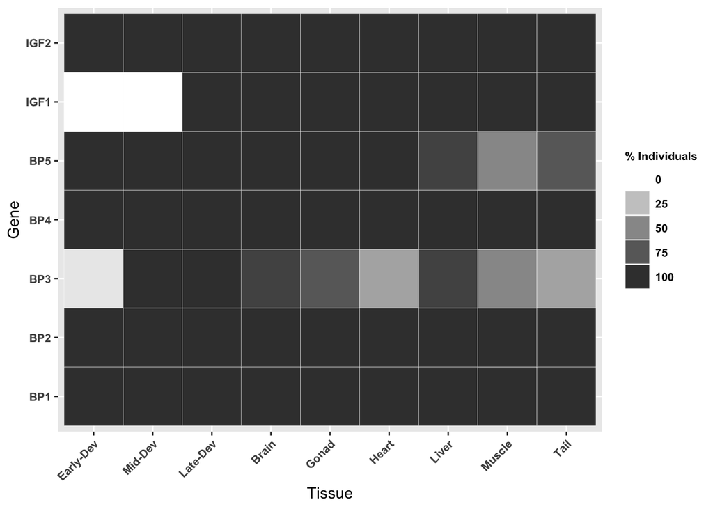

```r
#Read in data set that includes the percent of individuals expressing each BP in each tissue type
#this is from the presence/absense PCR data
heat=read.csv("heatmap.data2.csv")
#Create a heatmap showing the varying amount of expression between ages and tissue types across genes
map=ggplot(data= heat, aes(x=as.factor(Stage), y=Gene)) +
geom_tile(aes(fill=Expression), colour="white") + scale_fill_gradient(low="white", high="grey24")+
  theme(axis.text.y= element_text(size=(8), face="bold"),
        legend.text = element_text(size = 8, face="bold"),
        legend.title = element_text(size=8, face="bold")) +
   guides(fill=guide_legend(title="% Individuals"))+
  scale_x_discrete(name = "Tissue", labels=c("Early-Dev", "Mid-Dev", "Late-Dev", "Brain", "Gonad", "Heart", "Liver", "Muscle", "Tail", "Reg. Tail")) +
  theme(axis.text.x = element_text(angle = 45, hjust = 1, face="bold", size=8))

ggsave(map, file="heatmap.expression.png", width=5, height=2, dpi=300)

map
```

##Visualize DATA AS A WHOLE SET with raw data

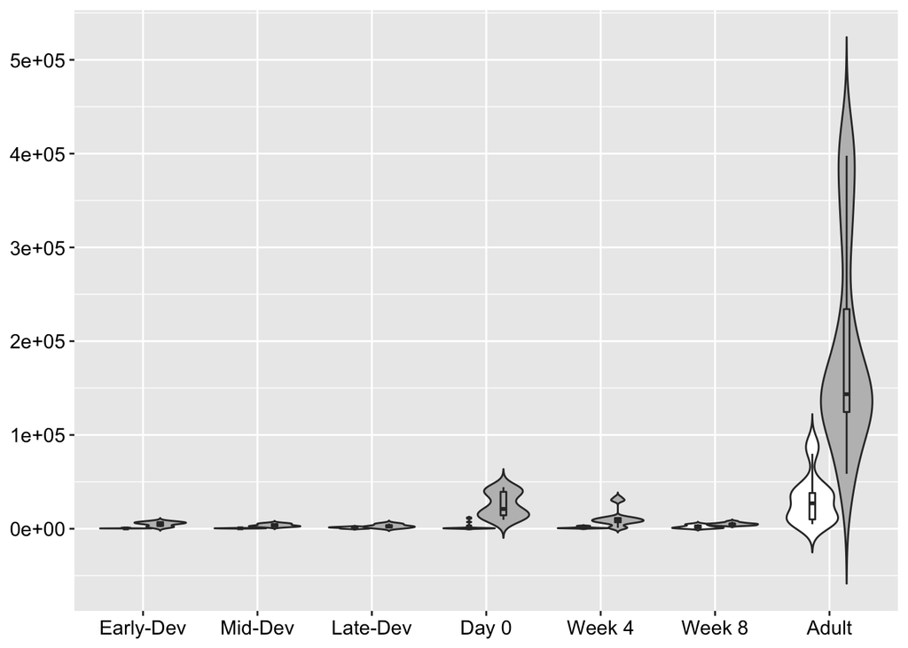

```r
##NOTE: all graphs are back transformed to normalized copy number for easy comparison and evaluation.

##Graph IGF1 and IGF2 expression across all life stages. Notice Life_Stage_Code is used to reorder the samples by age rather than the default alphebetized order in gpplot.
all.ages= ggplot(IGFs, aes(x=as.factor(Life_Stage_Code), y=Copy_Number, fill= Target)) +
  #this line creates a violin plot, not trimming the shape to hide data density on ends, and setting the width of the violins     to line up with the groups on the x axis.
  geom_violin(trim=F, position= dodge, scale="width") +
  #change the colors of IGF1 and IGF2 in the violin plot to white and grey fills respectively
  scale_fill_manual(values = c("white", "grey")) +
  #A boxplot is overlayed on the violin plot to show the mean and quartiles of the data, and all dataset outlies are          highlighted in red.
  geom_boxplot(width=0.1, position= dodge, outlier.shape = NA) +
  #Rename the x axis to display the developmental stages in "mid, early, and late" rather than numberical stages
  scale_x_discrete(name ="Life Stage",
                   labels=c("Early-Dev", "Mid-Dev", "Late-Dev", "Day 0", "Week 4", "Week 8", "Adult")) +
  #Change theme elements of the text used on the axis to remove the axis and plot titles, remove the legend, and bold the axis    text
  theme(axis.title.x = element_blank()) +
  theme(axis.title.y  = element_blank()) +
  theme(plot.title = element_blank()) +
  theme(legend.position="none") +
  theme(axis.text = element_text(face="bold") +
  theme(axis.text = element_text(size= 14)))

all.ages
```

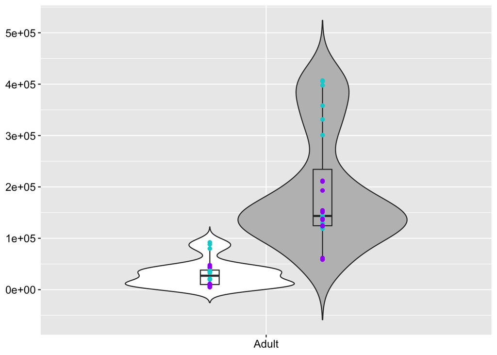

```r
##subset the IGF data to include only adult sames to visualize sex differences.
adult.sex=subset(IGFs, Life_Stage == "Adult")

##Plot the adult samples only, including data points colored by sex data
ad.sex= ggplot(adult.sex, aes(x=as.factor(Life_Stage_Code), y=Copy_Number, fill= Target)) +
    geom_violin(trim=F, position= dodge, scale="width") +
    scale_fill_manual(values = c("white", "grey")) +
  geom_boxplot(width=0.1, position= dodge, outlier.shape = NA) +
  geom_point(position= dodge, aes(group= Target, colour=Sex)) +
    scale_color_manual(values=c("purple", "darkturquoise","clear")) +
  labs(colour = "Sex") +
  scale_x_discrete(name ="Life Stage", labels=c("Adult")) +
  theme(axis.title.y = element_text(face="bold")) +
  theme(legend.title = element_text(face= "bold")) +
  theme(axis.title.x = element_blank()) +
    theme(axis.title.y  = element_blank()) +
    theme(plot.title = element_blank()) +
  theme(legend.position="none") +
    theme(axis.text = element_text(face="bold") +
  theme(axis.text = element_text(size= 14)))

ad.sex
```

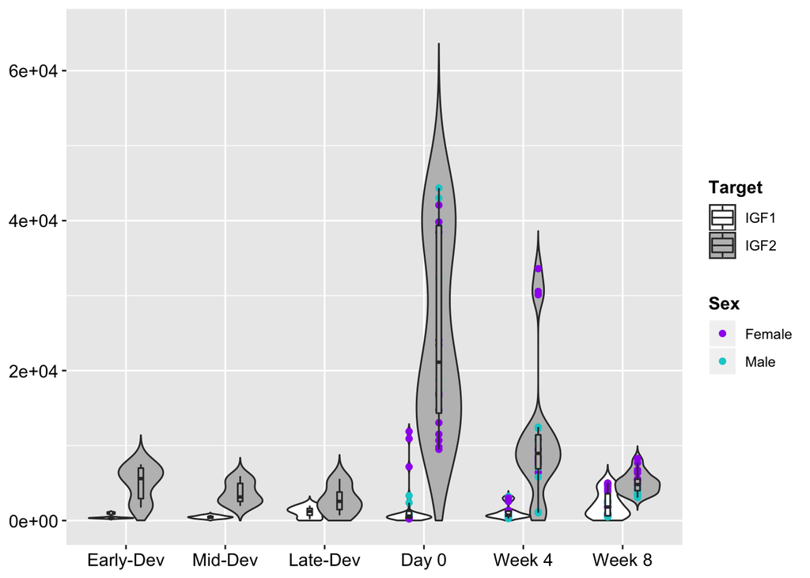

```r
##Subset IGF data set to include none of the adult samples for plotting purposes. The adult expression of both IGF1 and IGF2 is much higher than the expression at any other stage, making it difficult to visualize. The plot is recreated witout the adult samples to compare expression across development and juvenile growth more closely.
IGF_NA=subset(IGFs, Life_Stage != "Adult")

no.ad= ggplot(IGF_NA, aes(x=as.factor(Life_Stage_Code), y=Copy_Number, fill= Target)) +
    geom_violin(trim=F, position= dodge, scale="width") +
    scale_fill_manual(values = c("white", "grey")) +
    geom_point(position=dodge, aes(group= Target, colour=Sex)) +
  ##The na.translate tells it to include data points for the individuals with no sex, but to not annotate them in the legend. This can act up, so a second option is to create a blank label name in the legend for the NA points
  scale_color_manual(na.translate=FALSE, labels=c("Female", "Male", ""), values=c("purple", "darkturquoise","black")) +
  labs(colour = "Sex") +
   geom_boxplot(width=0.1, position= dodge, outlier.shape = NA) +
  scale_x_discrete(name ="Life Stage",
                   labels=c("Early-Dev", "Mid-Dev", "Late-Dev", "Day 0", "Week 4", "Week 8")) +
  scale_y_continuous(labels = function(x) format(x, scientific = TRUE), limits = c(0 , 65000)) +
  theme(axis.title = element_text(face="bold")) +
  theme(plot.title = element_blank()) +
  theme(legend.title = element_text(face= "bold")) +
  theme(axis.title.y  = element_blank()) +
    theme(axis.title.x  = element_blank())+
  theme(axis.text = element_text(face="bold")+
  theme(axis.text = element_text(size= 14)))

no.ad
```

##Export image for Journal

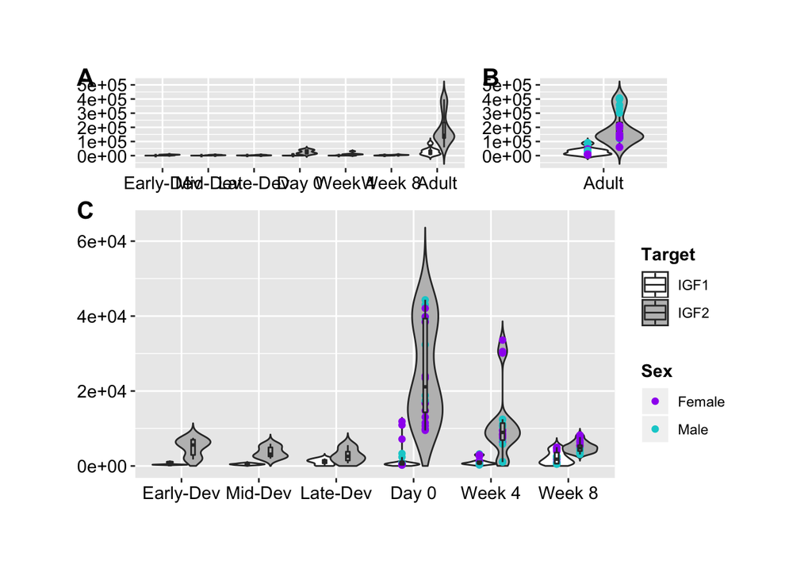

```r
##Load the cowplot package which will allow you to export the images in pre-determined proporations as one figure.
library("cowplot")
p=ggdraw() +
  #Export the first graph including all life stages. This graph will be on the top row, aligned along the left, take up 3/10 of the vertical space (beginning at 0.7/1 on the y-axis)+, and take up 6/10 of the horizontal space
  draw_plot(all.ages, x = 0, y = .7, width = .6, height = .3) +
  #Export the second graph including only the adult life stages. This graph will be on the top row, aligned to the right, and take up the reminaing 4/10 of the horizontal space on the top row.
  draw_plot(ad.sex, x = 0.6, y = .7, width = .3, height = .3) +
 #Export the third image, which is in the second row, and spans the entire length of the figure horizontally. Vertically it takes up the first 0.3/10 of the figure beginning at 0 on the y-axis.
  draw_plot(no.ad, x = 0, y = 0, width = 1, height = 0.7) +
 #Add labels to each of the figures. They will be labeled in the order that they are exported. The text size and exact coordiate placement is shown with the x and y values.
   draw_plot_label(label = c("A", "B","C"), size = 15,
                   #Note the y values are slightly above 1 on the top row, to avoid printing on top of                      the axis labels.
                  x = c(0, 0.6,0), y = c(1.02, 1.02,0.72))
# Add additional margin space to the edge of the graph to allow for formatting and editing of axis and graph titles.
p2= p + theme(plot.margin=unit(c(15,15,15,15),"mm"))

##Save the image as a png file with predefined dimensions. Add the dpi value to export it as publication quality.
ggsave(p2, file="publication.image.png", width=12, height=10, dpi=300)

p2
```

```r
adult.comp<- summarySE(adult.sex, measurevar="oqr", groupvars=c("Target"))
adult.comp
```

```
##   Target N oqr sd se ci
## 1   IGF1 0  NA NA NA NA
## 2   IGF2 0  NA NA NA NA
```

```r
animal.comp<- summarySE(Animal, measurevar="orq", groupvars=c("Target", "Life_Stage"))
animal.comp
```

```
##   Target Life_Stage  N         orq        sd         se         ci
## 1   IGF1      Adult 24  0.76775454 0.3746495 0.07647500 0.15820060
## 2   IGF1      Day 0 20 -0.91469909 0.8200321 0.18336476 0.38378684
## 3   IGF1     Week 4 20 -0.79050305 0.4417576 0.09878001 0.20674893
## 4   IGF1     Week 8 22 -0.50961783 0.4066841 0.08670533 0.18031361
## 5   IGF2      Adult 24  1.71749518 0.4184405 0.08541381 0.17669193
## 6   IGF2      Day 0 20  0.80991453 0.2101322 0.04698700 0.09834492
## 7   IGF2     Week 4 20  0.35217056 0.4446076 0.09941727 0.20808274
## 8   IGF2     Week 8 22  0.04959313 0.1775490 0.03785358 0.07872083
```